# Intro to tidy data

# Tidying Examples

```r
library(tidyverse)
```

## Are temperatures rising?

```r
temps = read_csv('../data/bristol_temps.csv')
knitr::kable(head(temps))
```

| year | jan | feb | mar | apr | may | jun | jul | aug | sep | oct | nov | dec |
| --- | --- | --- | --- | --- | --- | --- | --- | --- | --- | --- | --- | --- |
| 1900 | 5.3 | 3.6 | 4.3 | 9.3 | 11.2 | 15.0 | 18.9 | 16.5 | 15.2 | 11.0 | 8.0 | 7.8 |
| 1901 | 4.1 | 2.8 | 5.3 | 9.6 | 12.7 | 15.0 | 18.4 | 16.3 | 14.7 | 10.4 | 5.1 | 4.2 |
| 1902 | 5.6 | 2.2 | 7.6 | 8.2 | 10.1 | 14.5 | 16.2 | 15.9 | 14.1 | 10.6 | 7.6 | 5.1 |
| 1903 | 5.1 | 7.4 | 8.1 | 7.7 | 12.3 | 13.6 | 16.4 | 15.4 | 14.3 | 11.7 | 7.5 | 4.5 |
| 1904 | 5.0 | 4.5 | 5.1 | 9.7 | 11.8 | 14.5 | 18.1 | 16.2 | 13.4 | 10.3 | 6.3 | 5.3 |
| 1905 | 4.1 | 5.9 | 7.6 | 8.4 | 12.0 | 15.4 | 18.5 | 15.8 | 13.2 | 8.1 | 5.4 | 5.2 |

This data is messy. The values are temperatures in a month, in a year. So, we should have a column for month and a column for year. Yet, we have months on the columns and years on the rows. That means the data *is not tidy*. Tidy data might look something like this:

| year | month | temperature |
| --- | --- | --- |
| 1900 | jan | 5.3 |
| 1900 | feb | 3.6 |
| 1900 | mar | 4.3 |
| 1900 | apr | 9.3 |
| 1900 | may | 11.2 |
| 1900 | jun | 15.0 |
| 1900 | jul | 18.9 |
| 1900 | aug | 16.5 |
| 1900 | sep | 15.2 |
| 1900 | oct | 11.0 |
| 1900 | nov | 8.0 |
| 1900 | dec | 7.8 |

But, who cares? I can use the `rowMeans` function to get the average temperature in each year. That answers my question:

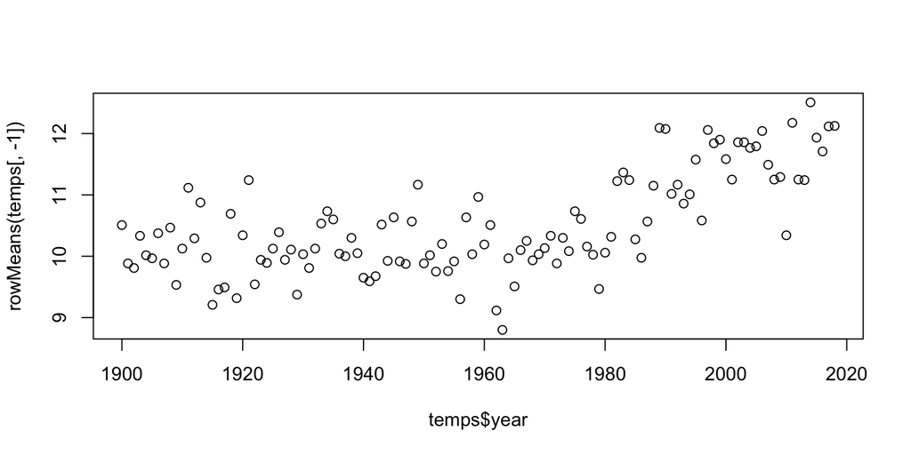

```r
plot(temps$year, rowMeans(temps[ , -1]))
```

But… if we want something that’s not the mean? We have `rowSums`, but no `rowSds`, `rowMedians`, basically anything else. However, if we had *tidy* data, we would not have to rely on special functions like `rowMeans`. So, let’s do something better.

The data currently has a variable (`month`) in its columns. Focusing on the *values* as we discussed above, there are only three variables: `year`, `month`, and `temperature`. If the data were tidy, then these would be the only columns.

To make data longer, we use the `pivot_longer` function:

```r
temps %>% pivot_longer(jan:dec)
```

```
## # A tibble: 1,428 x 3
##     year name  value
##    <dbl> <chr> <dbl>
##  1  1900 jan     5.3
##  2  1900 feb     3.6
##  3  1900 mar     4.3
##  4  1900 apr     9.3
##  5  1900 may    11.2
##  6  1900 jun    15
##  7  1900 jul    18.9
##  8  1900 aug    16.5
##  9  1900 sep    15.2
## 10  1900 oct    11
## # … with 1,418 more rows
```

This is *almost* our tidy example from above, except the column names are wrong. We can re-name the columns inside of the `pivot_longer` call:

```r
long_temps = temps %>% pivot_longer(jan:dec, names_to='month', values_to='temp')
knitr::kable(head(long_temps))
```

| year | month | temp |
| --- | --- | --- |
| 1900 | jan | 5.3 |
| 1900 | feb | 3.6 |
| 1900 | mar | 4.3 |
| 1900 | apr | 9.3 |
| 1900 | may | 11.2 |
| 1900 | jun | 15.0 |

Together, this gives us what we need to replicate the `rowMeans` solution in a tidy fashion. This would involve computing the average temperature in each year in this long data. That is, we need to *group* the data *by* a specific column, and then *summarize* the values within each group.

We can do that with `group_by` and `summarize`. `group_by` is an operation that collects together sets of rows based on a common value. Then, we typically use the `summarize()` function (or `summarise`) to transform the values in each group according to some rule. Here, we use the standard `R` `mean` function to get the mean of the temperatures in each group. This gives us a similar result to the `rowMeans` above.

```r
long_temps %>% group_by(year) %>% summarize(mean_temp = mean(temp))
```

```
## # A tibble: 119 x 2
##     year mean_temp
##    <dbl>     <dbl>
##  1  1900     10.5
##  2  1901      9.88
##  3  1902      9.81
##  4  1903     10.3
##  5  1904     10.0
##  6  1905      9.97
##  7  1906     10.4
##  8  1907      9.88
##  9  1908     10.5
## 10  1909      9.53
## # … with 109 more rows
```

We can plot this in the same way, or use `ggplot2` to make a plot that’s a little more pretty:

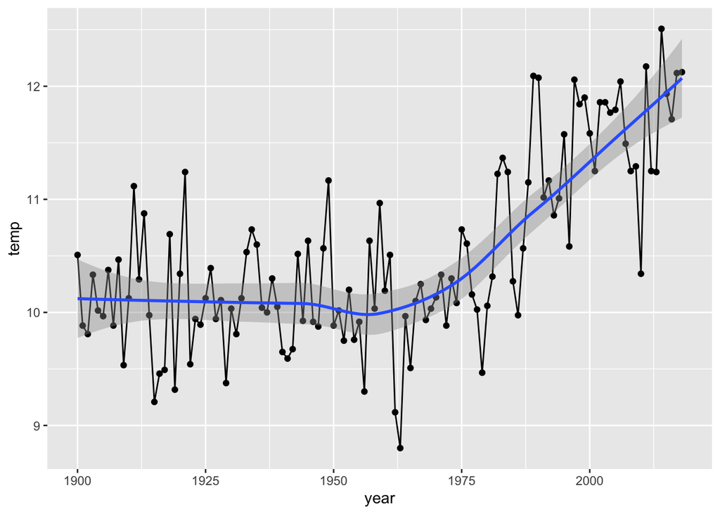

```r
long_temps %>%
          group_by(year) %>% # make the groups for each year
          summarize(temp = mean(temp)) %>% # get the average temperature
      ggplot(aes(x=year, y=temp)) + # plot the result
        geom_point() +
        geom_line() +
        geom_smooth()
```

Alternatively, with the tidy data already, we can plot the values by year in quite a few ways. Just as a bunch of dots in each year:

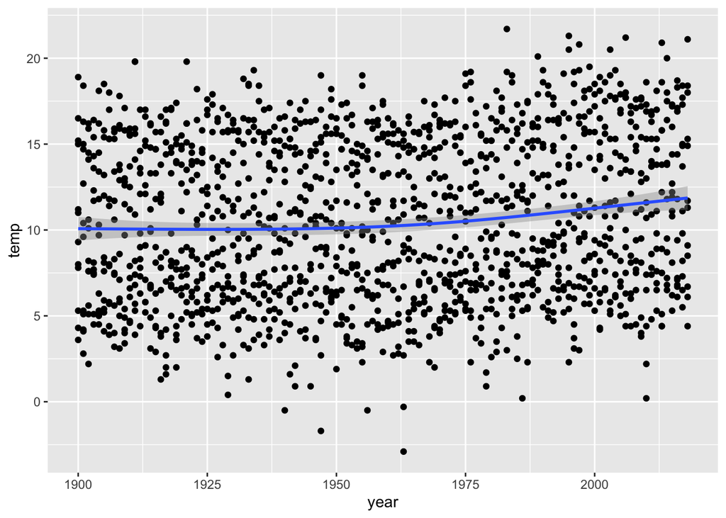

```r
ggplot(long_temps, aes(x=year, y=temp)) + geom_point() + geom_smooth()
```

or as a set of boxplots in each year:

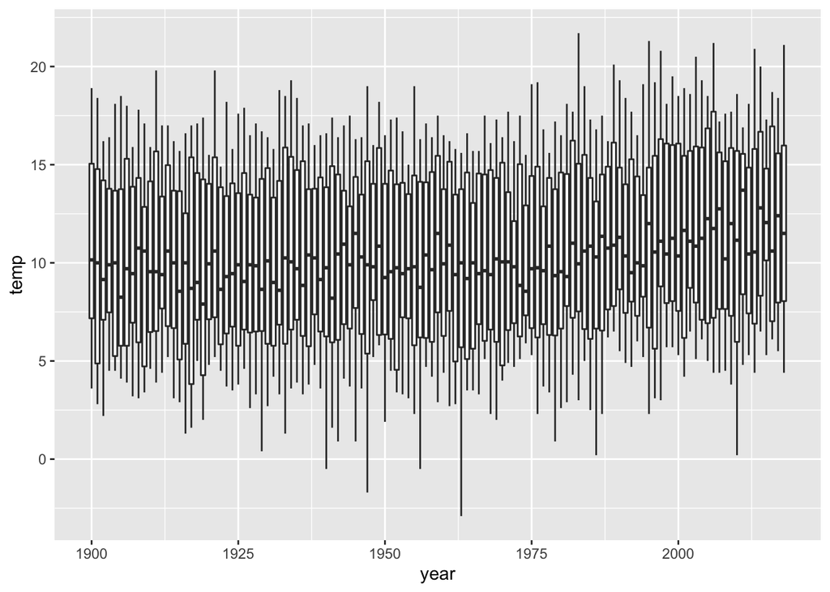

```r
ggplot(long_temps, aes(x=year, group=year, y=temp)) + geom_boxplot()
```

## What’s the climate curve for Bristol?

A *climate curve* shows the range of temperatures a place experiences every month. It’s kind of a standard summary of the climate of a place, and basically [every Wikipedia page on a place a version of one](https://en.wikipedia.org/wiki/Bristol#Climate). For this, we would need to get a summary of the typical temperature per month and plot *that*.

There are a few ways this could get done using the tidy data, but doing this with the standard data would be very verbose.

First, we could use the `group` option in `ggplot`:

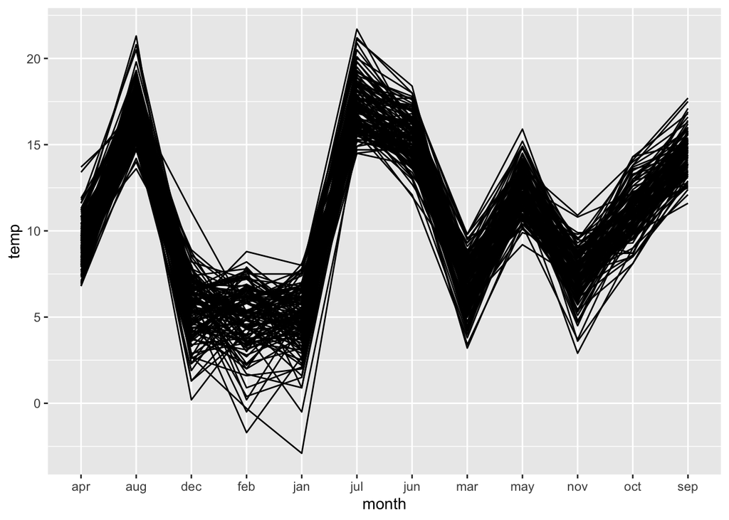

```r
ggplot(long_temps, aes(x=month, y=temp, group=year)) + geom_line()
```

But that doesn’t look quite right: it’s sorting the months in alphabetical order, not calendar order. We can force this order, though, by making the months an *ordered factor*, which is like a categorical variable with a set ordering. This is very simple to do, and requires us to first get the order of the factors. I’ll do this by taking them from our original un-tidy dataframe:

```r
month_order = colnames(select(temps, -year))
```

and the using `ordered` to force the months into an ordered categorical variable:

```r
long_temps['month'] = ordered(long_temps$month, levels=month_order)
```

Finally we can make our plot:

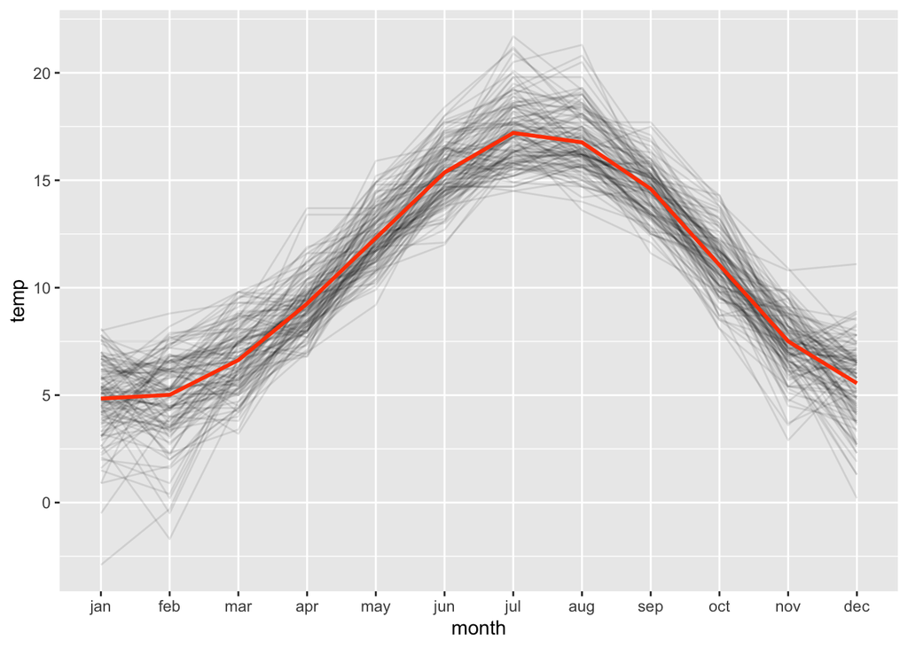

```r
long_temps %>% ggplot(aes(x=month, y=temp, group=year)) +
              geom_line(alpha=.1) +
              geom_smooth(color='orangered', se=F, aes(group=NA))
```

## What’s the relationship beteen Phosphate and Salinity?

This data contains information on sample sites in the ocean. It provides measures of nutrients, as well as information on the prevalence of species of phytoplankton.

```r
species = read_csv('../data/species.csv')
knitr::kable(head(species))
```

| Year | Date | Latitude | Longitude | Depth | A. robusta | A. unicornis | C. divergens | C. dentata | E. huxleyi | G. ericsonii | S. florida | NiCompounds | Phosphate | Silicate | Salinity | Temperature | Chlorophyll |
| --- | --- | --- | --- | --- | --- | --- | --- | --- | --- | --- | --- | --- | --- | --- | --- | --- | --- |
| 2003 | 2003-05-22 | -29.5 | -26.9 | 13 | 0.00000 | 60.75334 | 0.000 | 0 | 1761.8469 | 1397.3269 | 0 | 0.080900 | 0.0991000 | 1.08 | 35.804 | 21.330 | 0.03 |
| 2003 | 2003-05-22 | -29.5 | -26.9 | 116 | 353.35689 | 117.78563 | 0.000 | 0 | 353.3569 | 1060.0707 | 0 | 2.402083 | 0.3227000 | 1.32 | 35.740 | 17.220 | 0.11 |
| 2003 | 2003-05-24 | -21.6 | -25.0 | 22 | 71.27584 | 0.00000 | 0.000 | 0 | 997.8617 | 142.5517 | 0 | 0.012900 | 0.2010156 | 1.07 | 37.290 | 26.618 | 0.03 |
| 2003 | 2003-05-24 | -21.6 | -25.0 | 34 | 0.00000 | 112.10762 | 0.000 | 0 | 1681.6143 | 224.2152 | 0 | 0.013100 | 0.2034769 | 1.08 | 37.291 | 26.620 | 0.03 |
| 2003 | 2003-05-24 | -21.6 | -25.0 | 60 | 0.00000 | 102.45902 | 102.459 | 0 | 1434.4262 | 2356.5574 | 0 | 0.016300 | 0.2082746 | 1.10 | 37.290 | 26.624 | 0.03 |
| 2003 | 2003-05-24 | -21.6 | -25.0 | 140 | 186.56716 | 0.00000 | 0.000 | 0 | 149.2537 | 298.5075 | 0 | 0.025800 | 0.3755803 | 1.23 | 36.608 | 21.342 | 0.11 |

For this specific question, the data is actually tidy! the values for, say, the `Salinity` or `Phosphate` column represent the salinity of a specific sample site in the ocean. If we want to ask questions about the relationship between those *variables* for each of those *observations*, then the data is tidy enough:

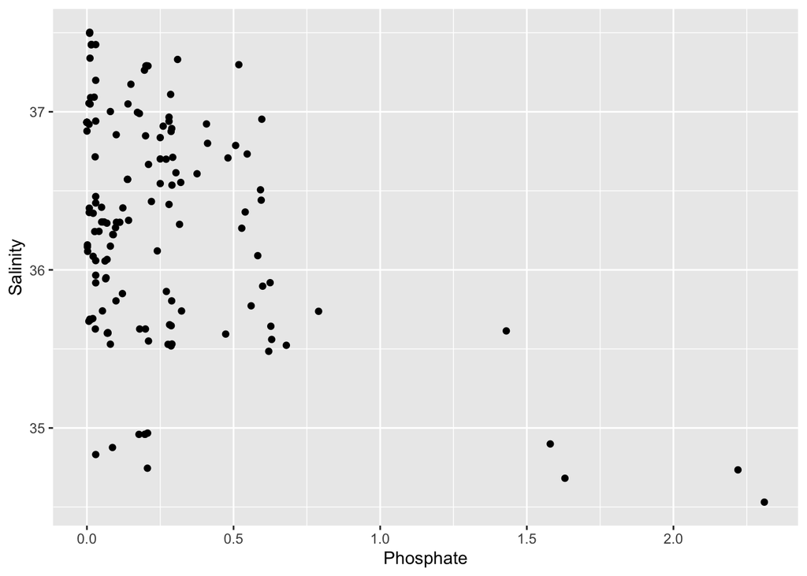

```r
species %>% ggplot(aes(x=Phosphate, y=Salinity)) + geom_point()
```

## What’s the species distribution?

However, an enterprising student will notice: the species/genera prevalence columns are not tidy! Each Genus is denoted by the first letter in the species name. So, the values in the column called `E. Huxleyi` **actually** reflects the *prevalence* (in organisms per volume) of the organism `E. Huxleyi`. Further, that column name **actually** mixes the genera & species name together! So, asking questions about the relationship between species and genera, or the co-occurence of genera/species has to tidy this data a bit.

To split the data up again, we can use `pivot_longer` again in the same way we did before:

```r
species_long = species %>% pivot_longer(`A. robusta`:`S. florida`, names_to=c("Genus", "Species"), names_sep='. ', values_to='prevalence')
```

But, note now that we’ve *duplicated* tons of measurements of the other rows! This automatically demonstrates why it’s sometimes not economical to input data in a tidy format… it often involves a lot of repetition! Now, though, we can look at the distributions of species/genera in our data, since each value of the `prevalence` column is a single observation of the prevalence of a single organism.

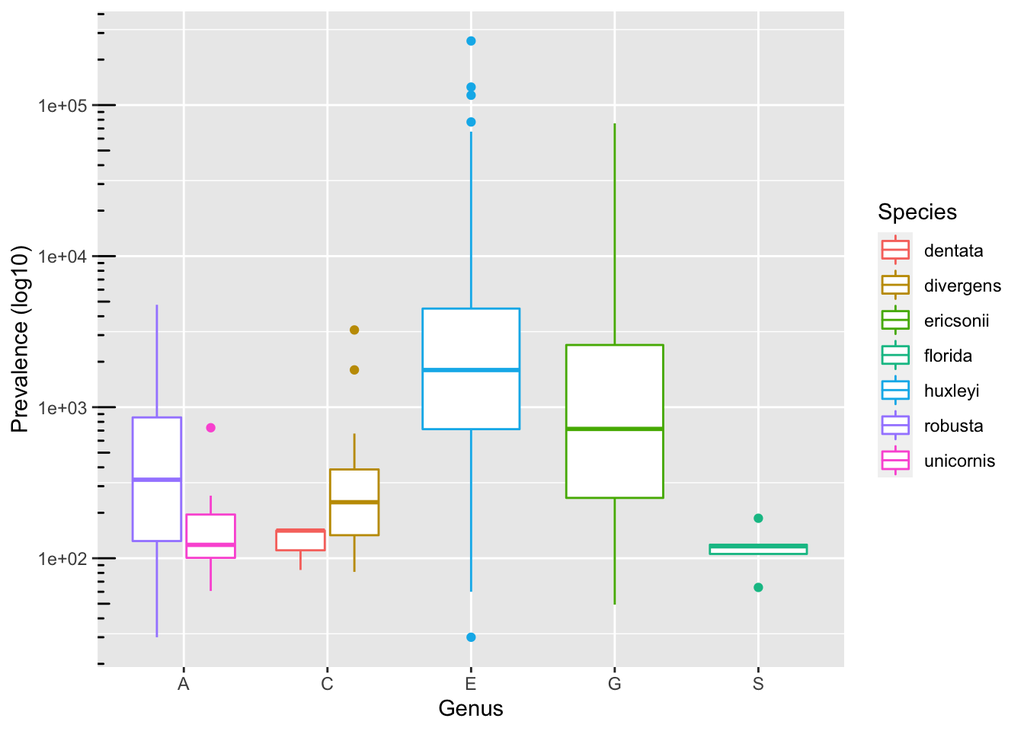

```r
species_long %>%
  ggplot(aes(x=Genus, y=prevalence, color=Species)) + geom_boxplot() +
  scale_y_continuous(trans='log10') + annotation_logticks(sides='l') + ylab("Prevalence (log10)")
```

# Lecture Notes

[Tidy Cheat Sheet](https://rstudio.com/wp-content/uploads/2015/02/data-wrangling-cheatsheet.pdf)

```r
# read in data
sites = read_csv('../data/species.csv')
temps = read_csv('../data/bristol_temps.csv')
# pivot longer

long_temps = temps %>% pivot_longer(jan:dec, names_to='month',
                                    values_to='temperature')
species = sites %>% pivot_longer(`A. robusta`:`S. florida`,
                                  values_to='prevalence',
                                  names_to='species_name')

# go back (broken)
species %>% pivot_wider(names_from = 'species_name', values_from='prevalence')
```

```
## # A tibble: 137 x 18
##     Year Date       Latitude Longitude Depth NiCompounds Phosphate Silicate
##    <dbl> <date>        <dbl>     <dbl> <dbl>       <dbl>     <dbl>    <dbl>
##  1  2003 2003-05-22    -29.5     -26.9    13      0.0809    0.0991     1.08
##  2  2003 2003-05-22    -29.5     -26.9   116      2.40      0.323      1.32
##  3  2003 2003-05-24    -21.6     -25      22      0.0129    0.201      1.07
##  4  2003 2003-05-24    -21.6     -25      34      0.0131    0.203      1.08
##  5  2003 2003-05-24    -21.6     -25      60      0.0163    0.208      1.1
##  6  2003 2003-05-24    -21.6     -25     140      0.0258    0.376      1.23
##  7  2003 2003-05-24    -21.6     -25     200      6.70      0.599      1.86
##  8  2003 2003-05-28     -6.5     -25      10      0.0265    0.289      1.09
##  9  2003 2003-06-01      8.5     -30.1     7      0.0171    0.0535     1.11
## 10  2003 2003-06-01      8.5     -30.1    15      0.0164    0.0587     1.11
## # … with 127 more rows, and 10 more variables: Salinity <dbl>,
## #   Temperature <dbl>, Chlorophyll <dbl>, `A. robusta` <list>, `A.
## #   unicornis` <list>, `C. divergens` <list>, `C. dentata` <list>, `E.
## #   huxleyi` <list>, `G. ericsonii` <list>, `S. florida` <list>
```

```r
# go back (reducing duplicates)
species %>% pivot_wider(names_from = 'species_name', values_from='prevalence', values_fn=mean)
```

```
## # A tibble: 137 x 18
##     Year Date       Latitude Longitude Depth NiCompounds Phosphate Silicate
##    <dbl> <date>        <dbl>     <dbl> <dbl>       <dbl>     <dbl>    <dbl>
##  1  2003 2003-05-22    -29.5     -26.9    13      0.0809    0.0991     1.08
##  2  2003 2003-05-22    -29.5     -26.9   116      2.40      0.323      1.32
##  3  2003 2003-05-24    -21.6     -25      22      0.0129    0.201      1.07
##  4  2003 2003-05-24    -21.6     -25      34      0.0131    0.203      1.08
##  5  2003 2003-05-24    -21.6     -25      60      0.0163    0.208      1.1
##  6  2003 2003-05-24    -21.6     -25     140      0.0258    0.376      1.23
##  7  2003 2003-05-24    -21.6     -25     200      6.70      0.599      1.86
##  8  2003 2003-05-28     -6.5     -25      10      0.0265    0.289      1.09
##  9  2003 2003-06-01      8.5     -30.1     7      0.0171    0.0535     1.11
## 10  2003 2003-06-01      8.5     -30.1    15      0.0164    0.0587     1.11
## # … with 127 more rows, and 10 more variables: Salinity <dbl>,
## #   Temperature <dbl>, Chlorophyll <dbl>, `A. robusta` <dbl>, `A.
## #   unicornis` <dbl>, `C. divergens` <dbl>, `C. dentata` <dbl>, `E.
## #   huxleyi` <dbl>, `G. ericsonii` <dbl>, `S. florida` <dbl>
```

```r
# show how separate/unite work
species = species %>% separate(species_name, c('genus', 'species'), sep='. ')
species %>% unite('organism', genus, species, sep='. ')
```

```
## # A tibble: 1,001 x 13
##     Year Date       Latitude Longitude Depth NiCompounds Phosphate Silicate
##    <dbl> <date>        <dbl>     <dbl> <dbl>       <dbl>     <dbl>    <dbl>
##  1  2003 2003-05-22    -29.5     -26.9    13      0.0809    0.0991     1.08
##  2  2003 2003-05-22    -29.5     -26.9    13      0.0809    0.0991     1.08
##  3  2003 2003-05-22    -29.5     -26.9    13      0.0809    0.0991     1.08
##  4  2003 2003-05-22    -29.5     -26.9    13      0.0809    0.0991     1.08
##  5  2003 2003-05-22    -29.5     -26.9    13      0.0809    0.0991     1.08
##  6  2003 2003-05-22    -29.5     -26.9    13      0.0809    0.0991     1.08
##  7  2003 2003-05-22    -29.5     -26.9    13      0.0809    0.0991     1.08
##  8  2003 2003-05-22    -29.5     -26.9   116      2.40      0.323      1.32
##  9  2003 2003-05-22    -29.5     -26.9   116      2.40      0.323      1.32
## 10  2003 2003-05-22    -29.5     -26.9   116      2.40      0.323      1.32
## # … with 991 more rows, and 5 more variables: Salinity <dbl>,
## #   Temperature <dbl>, Chlorophyll <dbl>, organism <chr>, prevalence <dbl>
```

```r
#
species
```

```
## # A tibble: 1,001 x 14
##     Year Date       Latitude Longitude Depth NiCompounds Phosphate Silicate
##    <dbl> <date>        <dbl>     <dbl> <dbl>       <dbl>     <dbl>    <dbl>
##  1  2003 2003-05-22    -29.5     -26.9    13      0.0809    0.0991     1.08
##  2  2003 2003-05-22    -29.5     -26.9    13      0.0809    0.0991     1.08
##  3  2003 2003-05-22    -29.5     -26.9    13      0.0809    0.0991     1.08
##  4  2003 2003-05-22    -29.5     -26.9    13      0.0809    0.0991     1.08
##  5  2003 2003-05-22    -29.5     -26.9    13      0.0809    0.0991     1.08
##  6  2003 2003-05-22    -29.5     -26.9    13      0.0809    0.0991     1.08
##  7  2003 2003-05-22    -29.5     -26.9    13      0.0809    0.0991     1.08
##  8  2003 2003-05-22    -29.5     -26.9   116      2.40      0.323      1.32
##  9  2003 2003-05-22    -29.5     -26.9   116      2.40      0.323      1.32
## 10  2003 2003-05-22    -29.5     -26.9   116      2.40      0.323      1.32
## # … with 991 more rows, and 6 more variables: Salinity <dbl>,
## #   Temperature <dbl>, Chlorophyll <dbl>, genus <chr>, species <chr>,
## #   prevalence <dbl>
```

```r
# useful group_bys
species %>% group_by(Date, genus) %>%
  summarize(prevalence = sum(prevalence),
            n_species_seen = sum(prevalence > 0),
            n_species = n())
```

```
## # A tibble: 235 x 5
## # Groups:   Date [47]
##    Date       genus prevalence n_species_seen n_species
##    <date>     <chr>      <dbl>          <int>     <int>
##  1 2003-05-22 A           532.              1         4
##  2 2003-05-22 C             0               0         4
##  3 2003-05-22 E          2115.              1         2
##  4 2003-05-22 G          2457.              1         2
##  5 2003-05-22 S             0               0         2
##  6 2003-05-24 A           602.              1        10
##  7 2003-05-24 C           102.              1        10
##  8 2003-05-24 E          4425.              1         5
##  9 2003-05-24 G          3086.              1         5
## 10 2003-05-24 S             0               0         5
## # … with 225 more rows
```

```r
species %>% group_by(Date, genus) %>%
  summarize(prevalence = sum(prevalence),
            n_species_seen = sum(prevalence > 0),
            n_species = n()) %>%
  summarize(prevalence = sum(prevalence))
```

```
## # A tibble: 47 x 2
##    Date       prevalence
##    <date>          <dbl>
##  1 2003-05-22      5104.
##  2 2003-05-24      8215.
##  3 2003-05-28       353.
##  4 2003-06-01      5784.
##  5 2003-06-02     15253.
##  6 2003-06-03      6049.
##  7 2003-06-04     13539.
##  8 2003-06-05      3678.
##  9 2003-06-06     18009.
## 10 2003-06-07      5474.
## # … with 37 more rows
```

# All the functions you may want:

- `pivot_wider()`: take rows and convert them into columns
- `pivot_longer()`: take columns and convert them into rows
- `group_by(group_name) %>% summarize(group_summary = ..., group_summary2=...)`: split the dataframe into groups based on the unique values of `group_name` & summarize those groups using one (or more) functions
  - `count()/n()`: count the number of observations in the group
  - `first(variable)`: get the first value of `variable` in the group
  - `last(variable)`: get the last value of `variable` in the group
  - `n_distinct(variable)`: get the number of unique values of `variable` in the group. Gives the number of unqiue *rows* if `variable` is omitted.
- `filter()`: subset the data by rows according to some condition(s)
  - `between(variable, lower, higher)`: is `TRUE` for rows where the value of `variable` is at least as large as `lower` and at most as large as `higher`.
  - `distinct(variable)`: is `TRUE` for rows when the value for that row not yet been seen (going from the first row to the last row)
- `select()`: subset the data by columns according to some condition(s)
  - `contains(variable,value)`: is `TRUE` for rows where `variable` is a string that contains `value`. See `??tidy_select` for more.
- `mutate(new_variable = do_something(old_variable))`: add a `new_variable` to the data that is computed using an `old_variable` of the dataframe
  - `transmute(new_variable = do_something(old_variable))`: same as mutate, but only `new_variable` is returned
  - `rename(new_name = old_name)`: rename the `old_name` column to be called `new_name`
- `separate(variable, sep="_")/unite(variable1, variable2, sep="_")`: split (or join) a column into new columns based on a separator, `sep`
  - `separate_rows(variable, sep=':')`: split a column into *rows*, where each new row is a copy of the original, but now its value of `variable` has been split according to `sep`
- `arrange(variable)`: sort the dataframe based on increasing values of `variable` (i.e. sort is ascending)
  - `arrange(desc(variable))` sort the dataframe based on *decreasing* values of `variable`
- joins: merge dataframes based on set theory
  - `left/right/inner/full_join()`
  - `semi/anti_join`
- `expand_grid(a, b, c)`: make a new dataframe out of all the combinations of values in `a`, `b`, and `c`
  - `seq(start, stop, step)`: make a sequence from the `start` to the `stop` with a step size of `step`
  - `rep(vector, number)`: repeat the `vector`